# Pf6 metadata

Aris Paschalidis

2022-01-27

This file outlines how we compile the metadata for the Pf6 dataset. We first download the most basic metadata from the Pf6 website.

```r
temp_file <- tempfile()
download.file(
  "ftp://ngs.sanger.ac.uk/production/malaria/pfcommunityproject/Pf6/Pf_6_samples.txt",
  temp_file
)
meta <- data.table::fread(temp_file)
```

One of the key pieces of information we will later utilize is the country in which each sample was obtained. In some cases, it may be more useful to look on a broader scale at continents or subregions of sample.

```r
meta <- dplyr::mutate(
  meta,
  Continent = countrycode::countrycode(
    Country,
    origin = "country.name",
    destination = "continent"
  ),
  Subregion = countrycode::countrycode(
    Country,
    origin = "country.name",
    destination = "region23"
  ),
  .before = Country
)
```

We can then cluster our samples into suitably close regions, for which we assume the same PLMAF exists but without reducing our $n$. We can use a silhouette plot to visualize the optimum number of regions to guide our decisions.

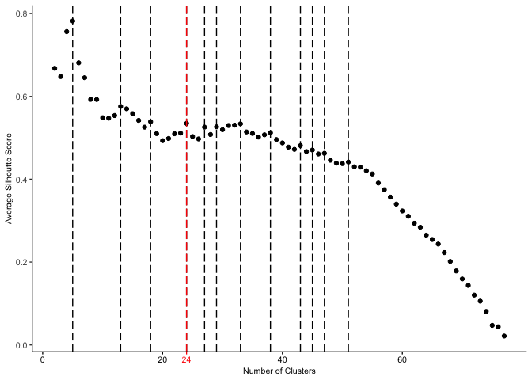

```r
# K Means
locations <- unique(meta[, c("Lat", "Long")])

sis <- 2:(nrow(locations) - 1)
for (k in sis) {
  si <- cluster::silhouette(cluster::pam(x = locations, k))
  sis[k - 1] <- mean(si[, 3])
}

# Silhouette plot
# N.B. element_line throws a warning when give it a list as an input. A
# workaround for this for making the number a different color is to use
# `ggtext::element_markdown`, but this does not work for making the tick mark
# another color
sil <- data.frame(
  cluster = seq_along(sis) + 1,
  sis = sis
)
ggplot(sil, aes(x = cluster, y = sis)) +
  geom_point() +
  geom_vline(xintercept = which(diff(sign(diff(sis))) == -2) + 2, linetype = 5) +
  geom_vline(xintercept = 24, linetype = 5, color = "red") +
  annotation_custom(
    grob = grid::segmentsGrob(gp = grid::gpar(col = "red", lwd = 2)),
    xmin = 24, xmax = 24, ymin = -0.025, ymax = -0.02
  ) +
  scale_x_continuous(breaks = c(0, 20, 24, 40, 60)) +
  labs(x = "Number of Clusters", y = "Average Silhoutte Score") +
  coiaf::theme_coiaf() +
  theme(
    axis.title = element_text(size = 8),
    axis.text.x = ggtext::element_markdown(color = c("black", "black", "red", "black", "black")),
    axis.ticks.x = element_line(color = c("black", "black", "red", "black", "black"))
  )
```

```r
# Clustering with 24 locations
ks <- cluster::pam(meta[, c("Lat", "Long")], k = 24)
meta$color <- as.factor(ks$clustering)
```

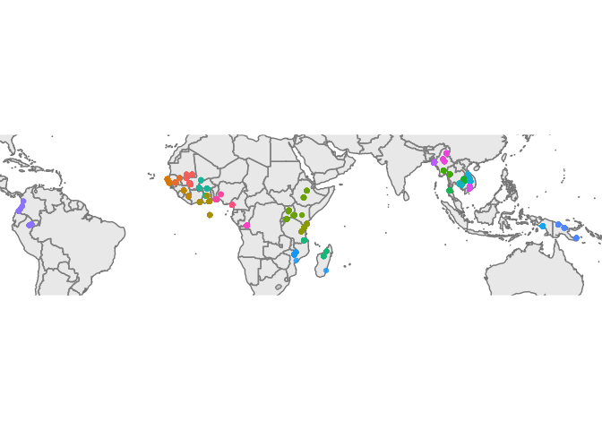

```r
ggplot(meta) +
  borders("world") +
  geom_polygon(
    data = map_data("world"),
    aes(x = long, y = lat, group = group),
    fill = "grey",
    alpha = 0.3
  ) +
  geom_point(aes(x = Long, y = Lat, color = color), alpha = 0.8) +
  theme_void() +
  theme(legend.position = "none") +
  scale_size(guide = "none") +
  coord_quickmap(xlim = c(-75, 150), ylim = c(-30, 30))
```

We may also be interested in the prevalence of malaria in various regions and the FwS metric.

```r
# Get the lat longs
coords <- data.frame(meta$Long, meta$Lat)
names(coords) <- c("x", "y")

# make column for 2-10 year old prevalence
meta$prev_2_10 <- as.numeric(meta$Year)
meta <- tidyr::drop_na(meta)

# get rasters using malariaAtlas package (this will take like 15 mins to download)
PfPR2_10 <- malariaAtlas::getRaster(
  surface = "Plasmodium falciparum PR2 - 10 version 2020",
  year = sort(unique(meta$prev_2_10))
)

# loop through and extra malaria prevalence
for (i in seq_along(sort(unique(meta$Year)))) {
  year <- sort(unique(meta$Year))[i]
  pos <- which(meta$Year == year)
  i_coords <- coords[pos, ]
  prev <- raster::extract(PfPR2_10[[i]], i_coords)
  meta$prev_2_10[pos] <- prev
}

meta
```

```
##         Sample             Study   Site Continent      Subregion    Country
##    1: FP0008-C 1147-PF-MR-CONWAY Kobeni    Africa Western Africa Mauritania
##    2: FP0009-C 1147-PF-MR-CONWAY Kobeni    Africa Western Africa Mauritania
##    3: FP0015-C 1147-PF-MR-CONWAY Kobeni    Africa Western Africa Mauritania
##    4: FP0016-C 1147-PF-MR-CONWAY Kobeni    Africa Western Africa Mauritania
##    5: FP0017-C 1147-PF-MR-CONWAY Kobeni    Africa Western Africa Mauritania
##            Lat      Long Year        ENA All samples same individual Population
##    1: 15.82083  -9.41450 2014 ERR1081237                    FP0008-C        WAF
##    2: 15.82083  -9.41450 2014 ERR1081238                    FP0009-C        WAF
##    3: 15.82083  -9.41450 2014 ERR1081239                    FP0015-C        WAF
##    4: 15.82083  -9.41450 2014 ERR1081240                    FP0016-C        WAF
##    5: 15.82083  -9.41450 2014 ERR1081241                    FP0017-C        WAF
##       % callable QC pass Exclusion reason Is returning traveller color
##    1:      82.16    TRUE     Analysis_set                  FALSE     1
##    2:      88.85    TRUE     Analysis_set                  FALSE     1
##    3:      88.45    TRUE     Analysis_set                  FALSE     1
##    4:      59.83    TRUE     Analysis_set                  FALSE     1
##    5:      89.02    TRUE     Analysis_set                  FALSE     1
##         prev_2_10
##    1: 0.004949389
##    2: 0.004949389
##    3: 0.004949389
##    4: 0.004949389
##    5: 0.004949389
##  [ reached getOption("max.print") -- omitted 6 rows ]
```

```r
fws <- read.csv("ftp://ngs.sanger.ac.uk/production/malaria/pfcommunityproject/Pf6/Pf_6_fws.txt", sep = "\t")
fws
```

```
##      Sample       Fws
## 1  FP0008-C 0.8183501
## 2  FP0009-C 0.9971406
## 3  FP0015-C 0.9283131
## 4  FP0016-C 0.9416369
## 5  FP0017-C 0.8752722
## 6  FP0018-C 0.9975290
## 7  FP0020-C 0.9931454
## 8  FP0021-C 0.9925694
## 9  FP0022-C 0.9926634
## 10 FP0023-C 0.9905923
## 11 FP0024-C 0.9651928
## 12 FP0025-C 0.5830603
## 13 FP0028-C 0.9959394
## 14 FP0029-C 0.9984377
```

[output cut: 37 more lines]

Finally, we can combine all our metadata together and save.

```r
combine_meta <- dplyr::left_join(meta, fws, by = "Sample")

saveRDS(combine_meta, here::here("metadata", "pf6_meta.rds"))
```